# ML-008:Procesado de variables con ScikitLearn

```python
%reload_ext watermark
%watermark
```

```
2019-05-30T21:34:58+02:00

CPython 3.6.5
IPython 6.4.0

compiler   : GCC 7.2.0
system     : Linux
release    : 5.1.5-arch1-2-ARCH
machine    : x86_64
processor  :
CPU cores  : 4
interpreter: 64bit
```

## Procesado de variables

```python
%matplotlib inline
import numpy as np
import pandas as pd
import matplotlib.pyplot as plt
import seaborn as sns
```

```python
datos = pd.read_csv("../../RESOURCES/datos_procesamiento.csv")
datos.head()
```

|  | col_inexistente1 | col2 | col3 | col_outliers | col_outliers2 | col_categorica | col_ordinal | col_texto |
| --- | --- | --- | --- | --- | --- | --- | --- | --- |
| 0 | 59.0 | 52.0 | 2.232832 | -50 | 0.771666 | ratón | muy bien | Tenía en su casa una ama que pasaba de los cua... |
| 1 | 31.0 | 74.0 | 0.906147 | -5 | 1.068558 | elefante | regular | El resto della concluían sayo de velarte, calz... |
| 2 | 81.0 | 28.0 | 0.626750 | -32 | 0.846396 | ratón | muy mal | El resto della concluían sayo de velarte, calz... |
| 3 | 34.0 | 16.0 | 0.816738 | -84 | 0.637381 | gato | mal | Una olla de algo más vaca que carnero, salpicó... |
| 4 | 32.0 | 28.0 | 0.571131 | 65 | 4.540614 | gato | bien | Tenía en su casa una ama que pasaba de los cua... |

```python
datos.dtypes
```

```
col_inexistente1    float64
col2                float64
col3                float64
col_outliers          int64
col_outliers2       float64
col_categorica       object
col_ordinal          object
col_texto            object
dtype: object
```

```python
datos.shape
```

```
(1000, 8)
```

## Variables numéricas

### Imputacion de datos

```python
from sklearn import preprocessing
```

```python
#Seleccionamos todas aquellas columnas que sean int o float, quitando asi las de string
var_numericas_df = datos.select_dtypes([int,float])
var_numericas_df.columns
```

```
Index(['col_inexistente1', 'col2', 'col3', 'col_outliers', 'col_outliers2'], dtype='object')
```

```python
#vamos a ver cuantos casos son NaN
var_numericas_df[var_numericas_df.isnull().any(axis=1)].shape
```

```
(96, 5)
```

```python
var_numericas_df[var_numericas_df.isnull().any(axis=1)].head()
```

|  | col_inexistente1 | col2 | col3 | col_outliers | col_outliers2 |
| --- | --- | --- | --- | --- | --- |
| 9 | NaN | 53.0 | 2.270999 | 62 | 1.067230 |
| 10 | NaN | 99.0 | 1.394209 | 98 | 4.145716 |
| 16 | NaN | 50.0 | 0.437365 | 59 | 20.549474 |
| 17 | NaN | 73.0 | 0.324893 | 98 | 0.761684 |
| 23 | NaN | 85.0 | 3.664671 | -48 | 3.154153 |

```python
#mediante el imputador preprocesamos el dataset mediante una estrategia, en este caso la media.
imputador = preprocessing.Imputer(strategy="mean")
```

```python
var_numericas_imputadas = imputador.fit_transform(var_numericas_df)
```

```python
var_numericas_imputadas
```

```
array([[ 59.        ,  52.        ,   2.23283208, -50.        ,
          0.77166646],
       [ 31.        ,  74.        ,   0.90614714,  -5.        ,
          1.06855838],
       [ 81.        ,  28.        ,   0.62675042, -32.        ,
          0.84639576],
       ...,
       [ 19.        ,  53.        ,   0.73723413,  73.        ,
          1.34525201],
       [ 88.        ,  94.        ,   0.76008706,  68.        ,
          1.3692463 ],
       [ 94.        ,  56.        ,   1.2299403 ,  61.        ,
          0.94395714]])
```

```python
#convertimos el array de numpy del imputador a un dataframe
var_numericas_imputadas_df = pd.DataFrame(
    var_numericas_imputadas,index=var_numericas_df.index,columns=var_numericas_df.columns
)
var_numericas_imputadas_df.head(10)
```

|  | col_inexistente1 | col2 | col3 | col_outliers | col_outliers2 |
| --- | --- | --- | --- | --- | --- |
| 0 | 59.000000 | 52.0 | 2.232832 | -50.0 | 0.771666 |
| 1 | 31.000000 | 74.0 | 0.906147 | -5.0 | 1.068558 |
| 2 | 81.000000 | 28.0 | 0.626750 | -32.0 | 0.846396 |
| 3 | 34.000000 | 16.0 | 0.816738 | -84.0 | 0.637381 |
| 4 | 32.000000 | 28.0 | 0.571131 | 65.0 | 4.540614 |
| 5 | 81.000000 | 4.0 | 1.618844 | 51.0 | 0.812940 |
| 6 | 57.000000 | 31.0 | 0.167880 | 78.0 | 1.235137 |
| 7 | 34.000000 | 20.0 | 20.229813 | 93.0 | 1.283176 |
| 8 | 37.000000 | 96.0 | 2.407978 | 54.0 | 1.298613 |
| 9 | 48.382743 | 53.0 | 2.270999 | 62.0 | 1.067230 |

```python
#Comprobamos que ahora ya no hay variables nulas
var_numericas_imputadas_df[var_numericas_imputadas_df.isnull().any(axis=1)].shape
```

```
(0, 5)
```

### Estandarizacion

El proceso de estandarizacion es un proceso requerido en el que el objetivo es obtener una variable con media 0 y desviacion estandar 1

```python
var_numericas_df.columns
```

```
Index(['col_inexistente1', 'col2', 'col3', 'col_outliers', 'col_outliers2'], dtype='object')
```

```python
#ibtenemos la media de cada una de las columnasabs
var_numericas_df.mean()
```

```
col_inexistente1     48.382743
col2                 49.660000
col3                  1.466095
col_outliers          4.253000
col_outliers2       131.193340
dtype: float64
```

```python
#obtenemos la desviacion estandar de cada una de las columnas
var_numericas_df.std()
```

```
col_inexistente1      27.987174
col2                  28.272668
col3                   1.732358
col_outliers          78.145901
col_outliers2       3401.164776
dtype: float64
```

Ahora procedemos a estandarizar el dataframe, para ello utilizaremos una herramienta de sklearn: **StandardScaler**

```python
escalador = preprocessing.StandardScaler()
var_numericas_imputadas_escalado_standard = escalador.fit_transform(var_numericas_imputadas)
```

```python
escalador.mean_
```

```
array([ 48.38274336,  49.66      ,   1.46609489,   4.253     ,
       131.19333968])
```

```python
#Observamos la media despues de la estandarizacion, en la que sus campos son muy proximos a 0
var_numericas_imputadas_escalado_standard.mean(axis=0)
```

```
array([-5.86197757e-17,  1.26121336e-16, -3.81916720e-17,  3.55271368e-18,
       -3.55271368e-18])
```

```python
#Observamos la desviacion estandard y comprobamos que es 1
var_numericas_imputadas_escalado_standard.std(axis=0)
```

```
array([1., 1., 1., 1., 1.])
```

```python
#Observamos la primera observacion
var_numericas_imputadas_escalado_standard[0]
```

```
array([ 0.39921733,  0.08280686,  0.44281884, -0.69460006, -0.03836537])
```

Para aquellos datasets con valores muy extremos, esta herramienta no sería la mas apropiada y sería más optimo usar estimadores mas robustos (menos sensibles a los Outliers). Para ello podemos emplear **RobustScaler** que funciona substrayendo la mediana y escalando mediante el rango intercuartil (IQR). (Este escalador robusto funciona igual que el anterior, salvo por la diferencia de que en vez de la media utiliza la mediana y en ver de la desviacion estandard utiliza el rango intercuartil)

```python
escalador_robusto = preprocessing.RobustScaler()
var_numericas_imputadas_escalado_robusto = escalador_robusto.fit_transform(var_numericas_imputadas)
```

```python
var_numericas_imputadas_escalado_robusto.mean(axis=0)
```

```
array([-3.81916720e-17, -2.85106383e-02,  4.01958704e-01,  3.04018692e-02,
        7.03130782e+01])
```

```python
var_numericas_imputadas_escalado_robusto.std(axis=0)
```

```
array([6.33218559e-01, 6.01245275e-01, 1.38651621e+00, 7.29970260e-01,
       1.83690817e+03])
```

### Escalado a un rango especifico.

Hay casos en los que en vez de estandarizar el modelo nos interesa mas ajustar los datos a un rango especifico (generalmente -1,1 o 0,1). Para ello utilizamos la herramienta **MinMaxScaler** que hace escalado minmax. Tambien podemos utilizar el MaxAbsScaler que simplemente divide cada valor de una variable por su valor maximo (y por tanto convierte el valor maximo a 1)

```python
#comprobamos el valor minimo antes del escalado
var_numericas_imputadas.min()
```

```
-100.0
```

```python
#comprobamos el valor maximo antes del escalado
var_numericas_imputadas.max()
```

```
107357.85777352
```

```python
#escalamos con la libreria preprocessing y la herramienta MinMaxScaler
escalador_minmax = preprocessing.MinMaxScaler()
var_numericas_imputadas_escalado_minmax = escalador_minmax.fit_transform(var_numericas_imputadas)
```

```python
#comprobamos el minimo despues de escalarlo
var_numericas_imputadas_escalado_minmax.min()
```

```
0.0
```

```python
#comprobamos el maximo despues de escalarlo
var_numericas_imputadas_escalado_minmax.max()
```

```
1.0
```

```python
#creamos ahora un escalador con la herramienta MaxAbsScaler
escalador_maxabs = preprocessing.MaxAbsScaler()
var_numericas_imputadas_escalado_maxabs = escalador_maxabs.fit_transform(var_numericas_imputadas)
```

```python
#comprobamos los maximos tras aplicar el escalador MaxAbs
var_numericas_imputadas_escalado_maxabs.max()
```

```
1.0
```

```python
#comprobamos los minimos tras aplicar el escalador MaxAbs y comprobamos que no se preocupa por el minimo y solo
#divide por el maximo
var_numericas_imputadas_escalado_maxabs.min()
```

```
-0.1122334455667789
```

Hay casos en los que es necesario tener observaciones con norma unitaria (norma L2 o euclidiana). Para estos casos se utilizará el método **normalizer**

```python
normalizador = preprocessing.Normalizer()
var_numericas_imputadas_normal = normalizador.fit_transform(var_numericas_imputadas)
```

```python
var_numericas_imputadas_normal[:1]
```

```
array([[ 0.63288908,  0.55780055,  0.02395144, -0.53634668,  0.00827761]])
```

```python
np.linalg.norm(var_numericas_imputadas[1,:])
```

```
80.39877436664493
```

### Otras transformaciones

Para aquellos casos en los que queremos aplicar una función arbitraria a una variable podemos usar **FunctionTransformer**. La variable *col3* no tiene una distribución normal, sino que tiene una asimetría muy marcada.

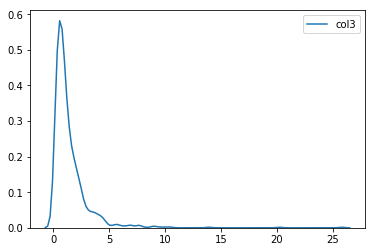

```python
sns.kdeplot(datos.col3)
```

Una práctica muy frecuente es aplicar el logaritmo a dichas variables para convertirlas a variables con una distribución más normal.

```python
from sklearn.preprocessing import FunctionTransformer
#la funcion np.log1p es para sumar siempre uno para evitar el logaritmo de 0 (que es infinito)
transformer = FunctionTransformer(np.log1p)
```

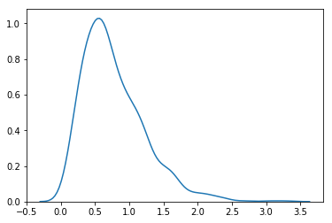

```python
col3_transformada= transformer.transform(datos[["col3"]])
col3_transformada = col3_transformada.reshape(col3_transformada.shape[0],)
sns.kdeplot(col3_transformada)
```

Vemos que tras aplicar el transformador de FunctionTransformer aplicando como parámetro la funcion logaritmo de numpy el resgistro de *col3* está mucho más normalizado

### Variables Categóricas

Los modelos están diseñados para trabajar con variables numéricas. Esto implica que para poder entrenar los modelos con variables categóricas tenemos que convertirlas a números. Este proceso se le conoce como **codificación**(*encoding*). Básicamente el proceso consiste en utilizar los registros de texto en valores ordinarios.

```python
datos = pd.read_csv("../../RESOURCES/datos_procesamiento.csv")
datos.head()
```

|  | col_inexistente1 | col2 | col3 | col_outliers | col_outliers2 | col_categorica | col_ordinal | col_texto |
| --- | --- | --- | --- | --- | --- | --- | --- | --- |
| 0 | 59.0 | 52.0 | 2.232832 | -50 | 0.771666 | ratón | muy bien | Tenía en su casa una ama que pasaba de los cua... |
| 1 | 31.0 | 74.0 | 0.906147 | -5 | 1.068558 | elefante | regular | El resto della concluían sayo de velarte, calz... |
| 2 | 81.0 | 28.0 | 0.626750 | -32 | 0.846396 | ratón | muy mal | El resto della concluían sayo de velarte, calz... |
| 3 | 34.0 | 16.0 | 0.816738 | -84 | 0.637381 | gato | mal | Una olla de algo más vaca que carnero, salpicó... |
| 4 | 32.0 | 28.0 | 0.571131 | 65 | 4.540614 | gato | bien | Tenía en su casa una ama que pasaba de los cua... |

```python
var_categoricas = datos[['col_categorica','col_ordinal']]
```

```python
var_categoricas.head()
```

|  | col_categorica | col_ordinal |
| --- | --- | --- |
| 0 | ratón | muy bien |
| 1 | elefante | regular |
| 2 | ratón | muy mal |
| 3 | gato | mal |
| 4 | gato | bien |

ahora debemos 'separar' estos valores por valores numéricos. A este proceso en Scikit Learn se conoce como **LabelEncoder**. En nuestro caso, como no queremos que los animales tengan un valor 'real' numerico (que no pueda darse una situación de que un ratón más un gato es igual a un elefante por ejemplo) lo que haremos será emplear una técnica conocida como **OneHotEncoder**.

### LabelEncoder

Aplicamos un transformador LabelEncoder()

```python
label_codificador_categorico=preprocessing.LabelEncoder()
label_codificador_categorico.fit_transform(datos.col_categorica)[:10]
```

```
array([3, 0, 3, 1, 1, 2, 2, 2, 0, 0])
```

### OneHotEncoder

Aplicamos un transformador OneHotEncoder()

```python
ohcodificador = preprocessing.OneHotEncoder()
```

```python
ohcodificador.fit(datos.col_categorica)
```

[output not shown]

[output cut: 101 more lines]

[output not shown]

Vemos que el transformador OneHotEncoder falla cuando recibe cadenas en vez de numeros. Por ello debemos convertir las variables categóricas a numéricas usando LabelEncoder.

```python
categorias_codificadas = label_codificador_categorico.transform(datos.col_categorica)
```

```python
categorias_codificadas
```

```
array([3, 0, 3, 1, 1, 2, 2, 2, 0, 0, 2, 0, 1, 3, 1, 3, 0, 3, 3, 0, 3, 3,
       3, 1, 1, 3, 1, 0, 1, 0, 0, 0, 0, 3, 0, 1, 0, 1, 1, 1, 1, 3, 0, 1,
       1, 2, 0, 1, 0, 2, 3, 2, 0, 3, 3, 1, 1, 0, 3, 2, 1, 1, 1, 1, 3, 0,
       0, 2, 1, 3, 2, 0, 1, 1, 3, 3, 0, 2, 3, 3, 0, 1, 2, 3, 1, 0, 0, 2,
       2, 2, 3, 1, 3, 1, 1, 0, 1, 1, 2, 2, 3, 2, 1, 0, 3, 2, 1, 1, 3, 1,
       2, 2, 2, 1, 2, 2, 0, 2, 3, 1, 1, 1, 1, 3, 3, 3, 2, 0, 0, 2, 3, 1,
       0, 1, 3, 3, 0, 1, 2, 3, 1, 0, 0, 0, 0, 2, 0, 0, 1, 3, 2, 2, 1, 2,
       2, 0, 1, 2, 2, 2, 2, 1, 3, 1, 1, 1, 2, 3, 3, 0, 3, 3, 0, 0, 3, 0,
       0, 0, 3, 3, 1, 2, 0, 0, 1, 1, 2, 0, 0, 0, 3, 2, 2, 1, 3, 1, 2, 3,
       0, 3, 3, 1, 3, 1, 3, 0, 1, 1, 2, 0, 2, 2, 1, 0, 0, 0, 1, 2, 1, 2,
       0, 0, 0, 0, 2, 1, 1, 0, 3, 2, 2, 3, 3, 2, 2, 0, 0, 2, 1, 2, 3, 2,
       3, 1, 3, 2, 0, 1, 1, 3, 3, 2, 1, 3, 3, 2, 0, 1, 3, 2, 0, 3, 0, 2,
       3, 2, 2, 2, 3, 3, 3, 2, 0, 2, 0, 1, 0, 0, 0, 0, 3, 0, 3, 0, 2, 3,
       1, 0, 2, 2, 3, 2, 3, 1, 1, 2, 1, 3, 2, 0, 1, 2, 1, 0, 2, 3, 1, 2,
       0, 0, 1, 3, 1, 0, 2, 2, 3, 1, 3, 1, 2, 1, 2, 3, 3, 2, 3, 1, 1, 3,
```

[output cut: 31 more lines]

```python
#obtenemos el total de registros
categorias_codificadas.shape
```

```
(1000,)
```

Aquí utilizamos el metodo resape en la lista obtenida de categorías_codificadas y para convertirla en una lista de listas, ya que el codificador de **OneHotEncoder** en su método fit_transform solo admite esto como parámetro.

```python
categorias_oh_codificadas = ohcodificador.fit_transform(categorias_codificadas.reshape(1000,1))
categorias_oh_codificadas
```

```
<1000x4 sparse matrix of type '<class 'numpy.float64'>'
	with 1000 stored elements in Compressed Sparse Row format>
```

Lo que nos devuelve el OneHotEncoder es más conocido como "matriz escasa" (sparse matrix) y es una manera de represesentar matrices con muchos ceros para consumir muy poca memoria. esta variable se puede convertir a una estructura de array de la siguiente forma:

```python
categorias_oh_codificadas.toarray()
```

```
array([[0., 0., 0., 1.],
       [1., 0., 0., 0.],
       [0., 0., 0., 1.],
       ...,
       [1., 0., 0., 0.],
       [1., 0., 0., 0.],
       [1., 0., 0., 0.]])
```

#### Eficiencia

Ahora realizaremos una comparación en memoria de una matriz escasa y su correspondiente np.array usando la función **sys.getsizeof** que nos devuelve el uso de memoria de un objeto de python en bytes.

```python
import sys
#Obtenemos el espacio de memoria en bytes de la matriz sparse
sys.getsizeof(categorias_oh_codificadas)
```

```
56
```

```python
#obtenemos el espacio de memoria en bytes del array de la matriz
sys.getsizeof(categorias_oh_codificadas.toarray())
```

```
32112
```

Podemos comprobar que es mucho más eficiente una matriz escasa antes que el array. Igualmente si queremos crear un transformador OneHotEncoder y almacenarlo en un np.array podemos hacerlo asignandole al parámetro sparse que sea igual a *False*

```python
oh_codificador = preprocessing.OneHotEncoder(sparse=False)
categorias_oh_codificadas = oh_codificador.fit_transform(categorias_codificadas.reshape(1000,1))
categorias_oh_codificadas
```

```
array([[0., 0., 0., 1.],
       [1., 0., 0., 0.],
       [0., 0., 0., 1.],
       ...,
       [1., 0., 0., 0.],
       [1., 0., 0., 0.],
       [1., 0., 0., 0.]])
```

```python
oh_codificador.feature_indices_
```

```
array([0, 4])
```

Pandas tiene la funcion auxiliar **get_dummies** que hace esto automáticamente de forma más facil

```python
pd.get_dummies(datos.col_categorica).head()
```

|  | elefante | gato | perro | ratón |
| --- | --- | --- | --- | --- |
| 0 | 0 | 0 | 0 | 1 |
| 1 | 1 | 0 | 0 | 0 |
| 2 | 0 | 0 | 0 | 1 |
| 3 | 0 | 1 | 0 | 0 |
| 4 | 0 | 1 | 0 | 0 |

### Texto

Veremos como vectorizar texto con el paquete feature_extraction de sklearn. Aplicaremos el ejemplo soble la columna col_texto que incluye frases del quijote.

```python
from sklearn import feature_extraction
datos.col_texto.values[:5]
```

```
array(['Tenía en su casa una ama que pasaba de los cuarenta, y una sobrina que no llegaba a los veinte, y un mozo de campo y plaza, que así ensillaba el rocín como tomaba la podadera.',
       'El resto della concluían sayo de velarte, calzas de velludo para las fiestas con sus pantuflos de lo mismo, los días de entre semana se honraba con su vellori de lo más fino.',
       'El resto della concluían sayo de velarte, calzas de velludo para las fiestas con sus pantuflos de lo mismo, los días de entre semana se honraba con su vellori de lo más fino.',
       'Una olla de algo más vaca que carnero, salpicón las más noches, duelos y quebrantos los sábados, lentejas los viernes, algún palomino de añadidura los domingos, consumían las tres partes de su hacienda.',
       'Tenía en su casa una ama que pasaba de los cuarenta, y una sobrina que no llegaba a los veinte, y un mozo de campo y plaza, que así ensillaba el rocín como tomaba la podadera.'],
      dtype=object)
```

Para convertir texto en variables numéricas, se puede proceder de igual forma que con las variables categóricas, simplemente separando las palabras antes. Para ello se utilizarán **vectorizadores** de sklearn que convierten el texto en vectores. **CountVectorizer** devuelve un vector con el valor 0 en todas las palabras que no existen en una frase y con el número de ocurrencias de las palabras que si existen.

Para que los conceptos queden claros, vamos a realizar un ejemplo que ejemplifique este concepto de forma más sencilla

```python
ejemplo_frases=['los coches son rojos',
               'los aviones son rojos',
               'los coches y los aviones son rojos',
               'los camiones son rojos'
               ]
vectorizador_count=feature_extraction.text.CountVectorizer()
x= vectorizador_count.fit_transform(ejemplo_frases)
x
```

```
<4x6 sparse matrix of type '<class 'numpy.int64'>'
	with 17 stored elements in Compressed Sparse Row format>
```

```python
pd.DataFrame(x.toarray(),columns=vectorizador_count.get_feature_names())
```

|  | aviones | camiones | coches | los | rojos | son |
| --- | --- | --- | --- | --- | --- | --- |
| 0 | 0 | 0 | 1 | 1 | 1 | 1 |
| 1 | 1 | 0 | 0 | 1 | 1 | 1 |
| 2 | 1 | 0 | 1 | 2 | 1 | 1 |
| 3 | 0 | 1 | 0 | 1 | 1 | 1 |

Esto realmente provoca un problema, y es que da mayor peso a aquellas palabras que aparecen muchas veces pero que no aporta valor semántico (por ejemplo, son o los).  
Para ello podemos utilizar el vectorizador TfidVectorizer() que realmente se encarga de medir la frecuencia del texto ya que es una medida que asigna valores a cada palabra en función de la frecuencia de aparición en todos los documentos.

```python
vectorizador_tfidf = feature_extraction.text.TfidfVectorizer()
```

```python
x = vectorizador_tfidf.fit_transform(ejemplo_frases)
pd.DataFrame(x.toarray(),columns=vectorizador_tfidf.get_feature_names())
```

|  | aviones | camiones | coches | los | rojos | son |
| --- | --- | --- | --- | --- | --- | --- |
| 0 | 0.000000 | 0.00000 | 0.657341 | 0.435087 | 0.435087 | 0.435087 |
| 1 | 0.657341 | 0.00000 | 0.000000 | 0.435087 | 0.435087 | 0.435087 |
| 2 | 0.464810 | 0.00000 | 0.464810 | 0.615306 | 0.307653 | 0.307653 |
| 3 | 0.000000 | 0.74187 | 0.000000 | 0.387139 | 0.387139 | 0.387139 |

Lo que ha hecho ha sido asignar 'pesos' de aparición en el texto. En el ejemplo vemos 'camiones' que la considera de más peso aunque solo aparece una vez.